# Making maps with sf

Rosie

11/4/2020

# Making maps in R

I’ve had a lot of people ask me to make maps for them recently. There seems to be a magical aura around cartography where people say “I can’t make maps” or “I don’t do GIS”. It’s really not that hard. IF you don’t want to pay the big `$$` for an ArcGIS licesne, you can make a quite servicable map with R.

There are a lot of different packages that you can use for map making, so one of the bigest issues folks have when they are first starting is knowing which package to start with.

‘sf’ which stands for “simple features” is one of the most user-friendly packages for basic map making (using vector graphics). It was built by the team that brought you the tidyvserse, so you know it’s probably good.

You can check out the website for more info: https://r-spatial.github.io/sf/

## A little background on GIS

In a normal data set, you will have a table where each observation is a row, and each attribute associated with that observation is a column.

We’ll use stations from EMP’s discrete water quality survey as an example.

```r
EMP = read.csv("EMP_Discrete_Water_Quality_Stations.csv")
EMP
```

```
##    Station                                           Location StationType
## 1      C10                  San Joaquin River near Vernalis   Shore-based
## 2     C10A         San Joaquin River near Vernalis @ SJR Club Shore-based
## 3       C3                 Sacramento River @ Green's Landing Shore-based
## 4      C3A                            Sacramento River @ Hood Shore-based
## 5       C7 San Joaquin River from Boat Dock @ Mossdale Bridge Shore-based
## 6       C9                  West Canal @ Clifton Court Intake Shore-based
## 7      D10                   Sacramento River @ Chipps Island Mid-channel
## 8      D11                          Sherman Lake near Antioch Mid-channel
## 9      D12           San Joaquin River @ Antioch Ship Channel Mid-channel
## 10    D14A                              Big Break near Oakley Mid-channel
## 11     D15                   San Joaquin River @ Jersey Point Mid-channel
## 12     D16               San Joaquin River @ Twitchell Island Mid-channel
## 13     D19                 Frank's Tract near Russo's Landing Mid-channel
## 14      D2                      Suisun Bay near Preston Point Mid-channel
```

[output cut: 73 more lines]

You will notice that we have one line per station with various attributes, such as Station Type, Location, Latitude, Longitude, and depth.

(I actually just made up the depths for demonstration purposes, don’t use them for anything else)

The columns “latitude” and “longitude” tell you were the stations are, but R won’t recognize this as spatial data in this format. We need to identify which columns have the spatial component and what the coordinate reference system is. If you are not familiar with coordinate reference systems, check out [this cheat sheet](https://www.nceas.ucsb.edu/sites/default/files/2020-04/OverviewCoordinateReferenceSystems.pdf)

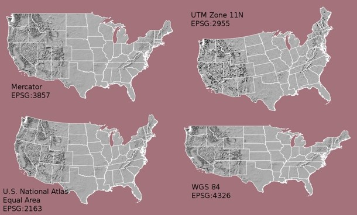

maps with different reference systems

### Components of a CRS

The coordinate reference system is made up of several key components:

- Coordinate system:The X, Y grid upon which your data is overlayed and how you define where a point is located in space.
- Horizontal and vertical units: The units used to define the grid along the x, y (and z) axis.
- Datum:A modeled version of the shape of the Earth which defines the origin used to place the coordinate system in space.
- Projection Information: The mathematical equation used to flatten objects that are on a round surface (e.g. the Earth) so you can view them on a flat surface (e.g. your computer screens or a paper map).

### Geographic versus projected CRS

A geographic coordinate system locates latitude and longitude location using angles. Thus the spacing of each line of latitude moving north and south is not uniform. (example, WGS84)

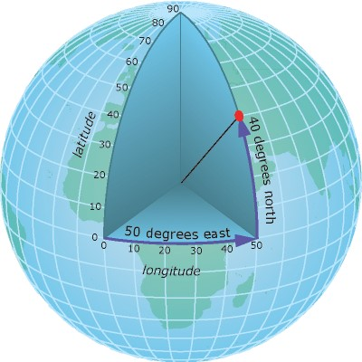

Geogrphic CRS

A projected coordinate system locates latitude and longitude using static units. The line spacing is uniform so it is easier to transform and do analyses. However, they are usually only good for a small part of the earth (Example UTM)

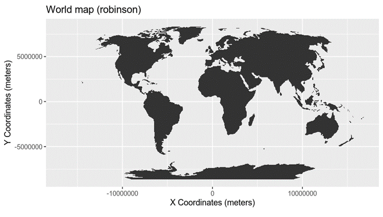

Projected CRS

We can specify the CRS via a list of the components, or by it’s [numeric code](https://spatialreference.org/) .

EMP uses WGS84, which is number 4326.

```r
library(sf)
EMPsf = st_as_sf(EMP, coords = c("Longitude", "Latitude"),  crs = 4326)

EMPsf
```

```
## Simple feature collection with 43 features and 5 fields
## Geometry type: POINT
## Dimension:     XY
## Bounding box:  xmin: -122.3907 ymin: 37.67575 xmax: -121.2647 ymax: 38.36771
## Geodetic CRS:  WGS 84
## First 10 features:
##    Station                                           Location StationType
## 1      C10                  San Joaquin River near Vernalis   Shore-based
## 2     C10A         San Joaquin River near Vernalis @ SJR Club Shore-based
## 3       C3                 Sacramento River @ Green's Landing Shore-based
## 4      C3A                            Sacramento River @ Hood Shore-based
## 5       C7 San Joaquin River from Boat Dock @ Mossdale Bridge Shore-based
## 6       C9                  West Canal @ Clifton Court Intake Shore-based
## 7      D10                   Sacramento River @ Chipps Island Mid-channel
## 8      D11                          Sherman Lake near Antioch Mid-channel
## 9      D12           San Joaquin River @ Antioch Ship Channel Mid-channel
## 10    D14A                              Big Break near Oakley Mid-channel
##      Status AverageDepth                   geometry
## 1  Inactive            3  POINT (-121.265 37.67575)
## 2    Active            4 POINT (-121.2647 37.67934)
## 3  Inactive            2 POINT (-121.5461 38.34575)
## 4    Active            1 POINT (-121.5205 38.36771)
## 5  Inactive            1 POINT (-121.3077 37.78607)
## 6    Active           45  POINT (-121.554 37.83095)
## 7    Active           23 POINT (-121.9183 38.04631)
## 8  Inactive           12 POINT (-121.7995 38.04229)
## 9    Active            6 POINT (-121.8063 38.02161)
## 10 Inactive           23 POINT (-121.7114 38.01776)
```

You will notice that instead of a “latitude” and “logitude” column, we now have a “geometry” column that contains both latitude and longitude.

Now let’s plot these points.

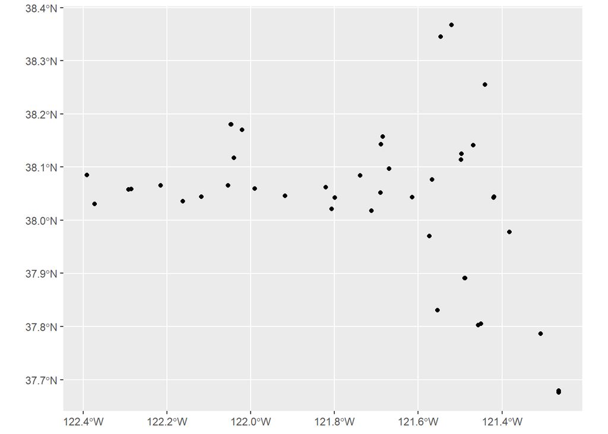

```r
library(ggmap)

ggplot() + geom_sf(data = EMPsf)
```

OK, so that’s pretty easy! But it would be nice if we had an outline of the waterways so the points aren’t floating out in space. I’ve got this shapefile of the waterways of teh Delta, and it’s pretty easy to import and plot it in sf.

```r
waterways = read_sf("hydro_delta_marsh.shp")
waterways
```

```
## Simple feature collection with 282 features and 0 fields
## Geometry type: POLYGON
## Dimension:     XY
## Bounding box:  xmin: -122.6408 ymin: 37.41522 xmax: -120.9357 ymax: 38.67781
## Geodetic CRS:  NAD83
## # A tibble: 282 x 1
##                                                                         geometry
##                                                                    <POLYGON [°]>
##  1 ((-121.5099 38.24711, -121.5104 38.24662, -121.5105 38.24661, -121.5106 38.2~
##  2 ((-121.5673 38.57437, -121.5674 38.5741, -121.5675 38.57397, -121.5677 38.57~
##  3 ((-121.5238 38.56153, -121.5238 38.56094, -121.524 38.56098, -121.5249 38.56~
##  4 ((-121.6011 38.55476, -121.6011 38.55453, -121.6011 38.55454, -121.6013 38.5~
##  5 ((-121.5456 38.55452, -121.5454 38.55412, -121.5453 38.554, -121.5452 38.553~
##  6 ((-121.6305 38.55163, -121.6304 38.55161, -121.6303 38.55168, -121.6302 38.5~
##  7 ((-121.6298 38.52384, -121.63 38.52377, -121.6305 38.52379, -121.6309 38.523~
##  8 ((-121.6384 38.51655, -121.6383 38.51642, -121.6386 38.51644, -121.6388 38.5~
##  9 ((-121.6315 38.51578, -121.6314 38.51575, -121.6311 38.51556, -121.6311 38.5~
## 10 ((-121.6825 38.5156, -121.6822 38.51557, -121.682 38.51551, -121.6817 38.515~
## # ... with 272 more rows
```

Notice that the ‘geometery’ column says ‘polygon’ instead of ‘point’ and it is actually a list with a bunch of points outlining the feature.

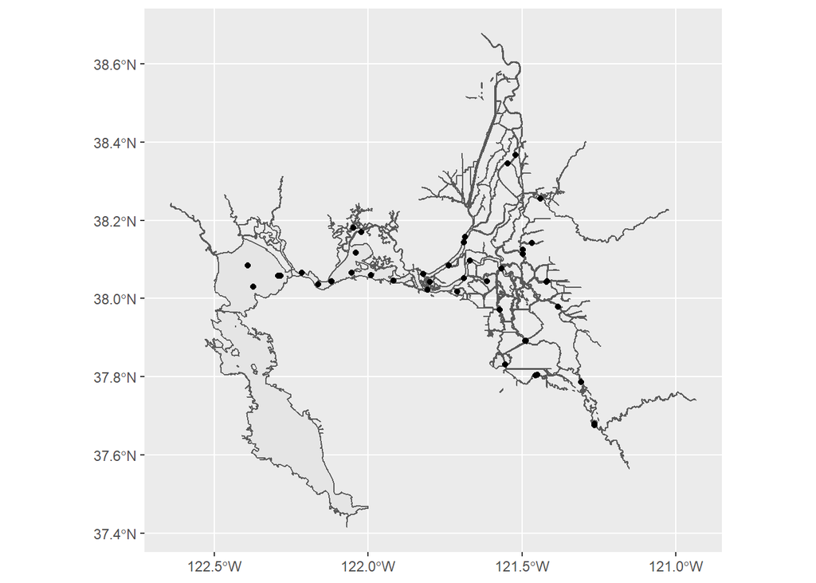

```r
ggplot() +
  geom_sf(data = waterways)+
  geom_sf(data = EMPsf)
```

## Tweaking the output

Excellent! Now let’s change some things. Fortunately, the ‘ggmap’ package can accept any of the ggplot themes, and all of the ggplot calls you might already know. You can also vary the shape, size, and color of the elements.

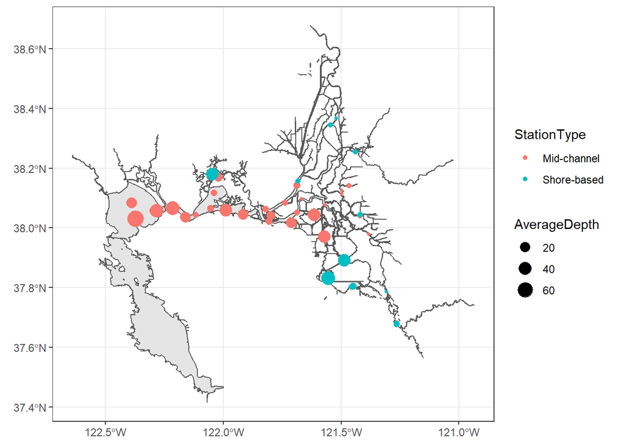

```r
ggplot() +
  geom_sf(data = waterways)+
  geom_sf(data = EMPsf, aes(color = StationType, size = AverageDepth)) +
  theme_bw()
```

We usually want a scale bar and north arrow on our maps. There are nice little built-in fucntions in the package “ggsn” that will do that for you.

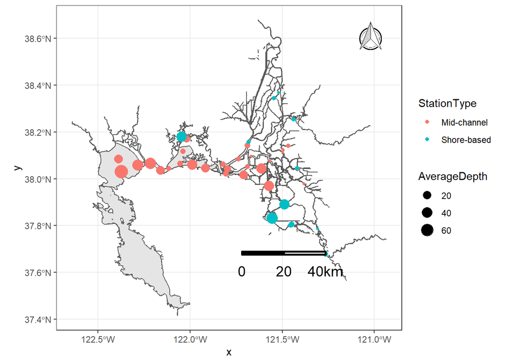

```r
library(ggsn)


ggplot() +
  geom_sf(data = waterways)+
  geom_sf(data = EMPsf, aes(color = StationType, size = AverageDepth)) +
  theme_bw()+

  #You can adjust the size, units, etc of your scale bar.
 scalebar(data = EMPsf, dist = 20, dist_unit = "km",
           transform = TRUE, st.dist = .1) +

  #there are a number of different options for north arrow symbols. ?north
  north(data = waterways, symbol = 2)
```

## Basemaps

We’d also like a basemap so we can see the rest of the world.

This is also a good opportunity to review rasters versus vectors. Spatial data can either be represented as a grid of equal-sized boxes, with data associated with each box (raster), or a group of polygons, with data associated with each point/line/polygon. The delta waterways shapefile is a vector - each river is made up of a list of points and has lines connecting the points.

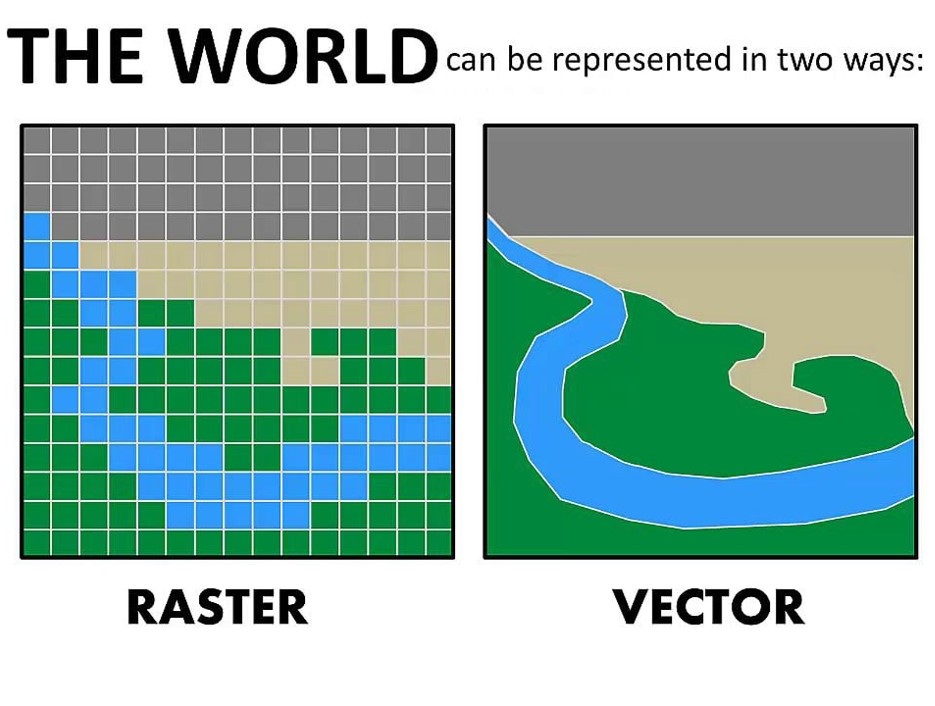

Diagram of rasters versus vectors

Basemaps are usually rasters, rather than vectors, and have very little information associated with them. Each pixel just has a color associated with it, so it’s just a picture of a map.

There are a number of free basemap sources online, including Google Maps, but Stamen maps are one of the easiest to work with.

[figure not shown]

```r
#download your map from online
basemap = get_stamenmap(bbox = c(left = -122.6,
                                 right = -121.0, bottom = 37.4, top = 38.7),
                        maptype = "terrain")

#use "ggmap" rather than "ggplot" to work with the basemap

ggmap(basemap)+ #plot the basemap

geom_sf(data = waterways, inherit.aes = F)+ #add teh waterways. Be sure to use "inherit.aes=F"

  geom_sf(data = EMPsf, aes(color = StationType, size = AverageDepth),inherit.aes = FALSE) + #add EMP

  #add scalebar and northa rrow
 scalebar(data = EMPsf, dist = 20, dist_unit = "km",
           transform = TRUE, st.dist = .1) +
  scale_color_discrete(guide = "none") +
  north(data = waterways, symbol = 2) +

    coord_sf(xlim = c(-122.6,-121),
           ylim = c(37.4, 38.7),
           expand = FALSE)
```

## Labels

We can label our points with `geom_sf_text` and add annotations with “annotate”

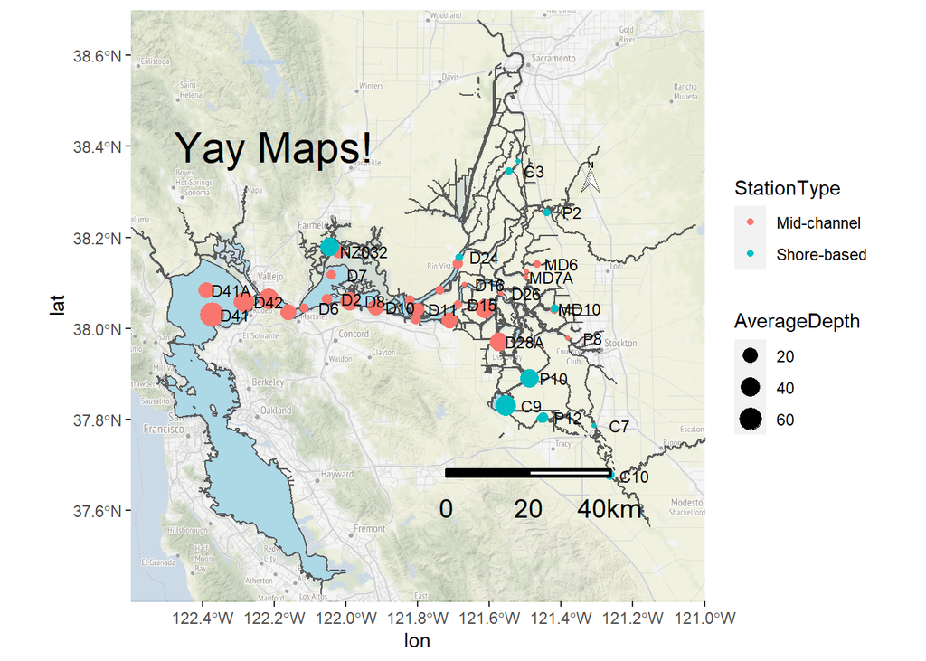

```r
ggmap(basemap, darken = c(.5, "white"))+ #plot the basemap and lighten it a little

  geom_sf(data = waterways, inherit.aes = F, fill = "lightblue")+ #add the waterways

  geom_sf(data = EMPsf, aes(color = StationType, size = AverageDepth),inherit.aes = FALSE) + #add EMP points

 scalebar(data = EMPsf, dist = 20, dist_unit = "km",
           transform = TRUE, st.dist = .1) + #add a scale bar

  north(data = EMPsf, symbol = 3) + #Add north arrow

geom_sf_text(data = EMPsf, aes(label = Station), #label the points
             nudge_x = 0.07, size = 3, #adjust size and position relative to points
             inherit.aes = FALSE,
             check_overlap = T) + #stop labels from being drawn over each other
annotate("text", label = "Yay Maps!", x = -122.2, y = 38.4, size = 8)
```

And there you have it. This map obviously needs a fair amount of work to be beautiful, but you can get it going relatively easily. If you need a copy of the Delta shapefile, check out the “deltamapr” package: https://github.com/InteragencyEcologicalProgram/deltamapr